# U.S. National Debt Over Time

Last updated: 2024-02-02

## Preliminary Work: Install/Load Packages

To try and ensure that this R Notebook will run successfully, we’ll use the [renv package](https://cran.r-project.org/web/packages/renv/index.html) to create a project-specific library of packages. This will allow us to install the packages that we need for this project without affecting any other projects that we may be working on. Additionally, the project library will track the specific versions of the dependency packages so that any updates to those packages will not break this project.

The code chunk below will first install the renv package if it is not already installed. Then we will load the package. Next, we’ll use the `restore()` function to install any packages listed in the renv.lock file. Once these packages are installed, we can load them into the R session using the `library()` commands. Below the code chunk, we’ll list out the packages that will be used in the project demo. And if you run into any trouble using renv, then you can use the second code chunk below and that should be an even more reliable approach to install the required packages.

```r
# Install renv package if not already installed
if(!"renv" %in% installed.packages()[,"Package"]) install.packages("renv")
# Load renv package
library(renv)
# Use restore() to install any packages listed in the renv.lock file
renv::restore(clean=TRUE, lockfile="../renv.lock")
# Load in the packages
library(httr2)
library(httpuv)
library(jsonlite)
library(tidyr)
library(ggplot2)
library(zoo)
```

- The [httr2 package](https://cran.r-project.org/package=httr2) lets us easily make the API calls for the data.
  - The original version of this demo used the httr package to perform the Example API Request and was updated in January 2024 to make use of the httr2 package. See the [httr2 announcement](https://www.tidyverse.org/blog/2023/11/httr2-1-0-0/) from November 2023 for more details about this update.
- The [httpuv package](https://cran.r-project.org/package=httpuv) is used by httr2 to perform the [HTTP requests](https://search.brave.com/search?q=HTTP).
- The [jsonlite package](https://cran.r-project.org/package=jsonlite) helps us read the JSON API response and transform it to R data.
- The [tidyr package](https://cran.r-project.org/package=tidyr) provides tools for working with the data.
- The [ggplot2 package](https://cran.r-project.org/package=ggplot2) lets us generate nice graphics to visualize the data.
- The [zoo package](https://cran.r-project.org/package=zoo) contains the `rollmean()` function that is used in some visualizations.
- The [rmarkdown package](https://cran.r-project.org/package=rmarkdown) is used to generate this R Notebook.

Since the rmarkdown functionality is built into RStudio, this one is automatically loaded when we open the RStudio. So no need to use the `library()` function for this one. Another observation to make about the code chunk above is that it is labeled as ‘setup’, which is a special name, which the R Notebook will recognize and automatically run prior to running any other code chunk. This is useful for loading in packages and setting up other global options that will be used throughout the notebook.

Then if you wish to try and update the versions of the various R packages in the lock file, you can use the `renv::update()` function to update the packages in the project library. However, it is possible that these updates could break the code in this notebook. If so, you may need to adapt the code to work with the updated packages.

My recommendation is to first run through the code using the versions of the packages in the lock file. Then if you want to try and update the packages, you can do so and then run through the code again to see if it still works. If not, you can always revert back to the lock file versions using the `renv::restore()` function.

If you update the packages and get everything working successfully, then you can update the lock file using the `renv::snapshot()` function. This will update the lock file with the versions of the packages that are currently installed in the project library. Then you can commit the updated lock file to the repository so that others can use the updated versions of the packages.

### Alternative Package Installation Code

If you run into any trouble using renv in the code chunk above, then you can use the code chunk below to install the required packages for this analysis. This method will first check if you have already installed the packages. If any are missing, it will then install them. Then it will load the packages into the R session. A potential flaw in this approach compared to using renv is that it will simply install the latest versions of the packages, which could potentially break some of the code in this notebook if any of the updates aren’t backwards compatible.

As long as you have downloaded the entire project repository, the renv chunk above will likely be managing the packages. Thus, the `eval=FALSE` option is used to prevent this chunk from running unless manually executed. So if you only downloaded this one Rmd file, this code chunk should take care of installing the packages for you.

```r
# Create list of packages needed for this exercise
list.of.packages = c("httr2","httpuv","jsonlite","tidyr","ggplot2","zoo","rmarkdown")
# Check if any have not yet been installed
new.packages = list.of.packages[!(list.of.packages %in% installed.packages()[,"Package"])]
# If any need to be installed, install them
if(length(new.packages)) install.packages(new.packages)
# Load in the packages
library(httr2)
library(httpuv)
library(jsonlite)
library(tidyr)
library(ggplot2)
library(zoo)
```

## Example API Request

The particular dataset that we’ll be working with is the [U.S. Treasury Monthly Statement of the Public Debt (MSPD)](https://fiscaldata.treasury.gov/datasets/monthly-statement-public-debt/summary-of-treasury-securities-outstanding). This dataset contains monthly observations of the U.S. national debt, broken down into various categories. The data is available for manual download in a variety of formats on the webpage, but for this example, we will use the [Fiscal Data API](https://fiscaldata.treasury.gov/api-documentation/) to programmatically import the data into R.

Before requesting the full data series for the national debt, we will replicate the example API request from the dataset website. Although we could directly use the `fromJSON()` function to make the request and parse the response in one step, we’ll first break this down into smaller steps to better understand the process.

#### Construct the API GET Request

First, we will specify the base url for the fiscal data API. This is the same for all requests to this API, so we can save it as a string to be used in each request.

```r
urlbase = "https://api.fiscaldata.treasury.gov/services/api/fiscal_service"
```

```r
urlend = "v1/debt/mspd/mspd_table_1"
urlfull = paste(urlbase,urlend,sep="/")
urlfull
```

```
[1] "https://api.fiscaldata.treasury.gov/services/api/fiscal_service/v1/debt/mspd/mspd_table_1"
```

After we create the url string for the table that we want, the next step is to specify any parameters for the API call, which effectively convey additional instructions for what data we want and how we want it returned. For this example, we want to (1) sort the data by its record date, (2) specify the requested data format for the response, and (3) retrieve only the first observation after the sorting.

The first character of each parameter indicates whether it is the first parameter or a subsequent parameter. The first parameter is indicated by `?` and each subsequent parameter is separated with an `&`.

1. The first parameter is `sort=-record_date`, which sorts the observations by the `record_date` variable in descending order. The `-` before `record_date` indicates that we want the dates in descending order so that the most recent observation is at the top.
2. The second parameter is `format=json`, which specifies the requested data format for the response. This [JSON format](https://search.brave.com/search?q=JSON+format) parameter is actually unnecessary since it is the default response format for the API, but if we wanted to receive csv or xml formatted response, we would specify that here.
3. The third parameter is `page[number]=1&page[size]=1`, which retrieves only the first observation after the sorting. This consists of two parts: `page[size]` specifies how any observations in each response and `page[number]` specifies which ‘page’ to request (if we wanted the second observation, then we would keep `page[size]` as is and switch to `page[number]=2`).

```r
opt1 = "?sort=-record_date"
opt2 = "&format=json"
opt3 = "&page[number]=1&page[size]=1"
req1 = paste(urlfull,opt1,opt2,opt3,sep='')
req1
```

```
[1] "https://api.fiscaldata.treasury.gov/services/api/fiscal_service/v1/debt/mspd/mspd_table_1?sort=-record_date&format=json&page[number]=1&page[size]=1"
```

#### Make the Request

Now, we’ll use the `request()` function from the httr2 package to save this url string as a request object. If we examine the contents of this object, `request1`, we can see that it transformed the text of the url into an API request that makes use of the GET method. See the [Brave Code LLM output](https://search.brave.com/search?q=RESTful+API) for more context around the methods for RESTful APIs.

```r
request1 = request(req1)
request1
```

```
<httr2_request>
GET
https://api.fiscaldata.treasury.gov/services/api/fiscal_service/v1/debt/mspd/mspd_table_1?sort=-record_date&format=json&page[number]=1&page[size]=1
Body: empty
```

Following the process outlined in the [httr2 announcement post](https://www.tidyverse.org/blog/2023/11/httr2-1-0-0/), we can do a dry run of a call to this API endpoint using the `req_dry_run()` function. That post also shows some examples for how you can further edit the parameters of your request using the functions beginning with `req_`.

```r
request1 |> req_dry_run()
```

```
GET /services/api/fiscal_service/v1/debt/mspd/mspd_table_1?sort=-record_date&format=json&page[number]=1&page[size]=1 HTTP/1.1
Host: api.fiscaldata.treasury.gov
User-Agent: httr2/1.0.0 r-curl/5.2.0 libcurl/8.3.0
Accept: */*
Accept-Encoding: deflate, gzip
```

```r
response1 = req_perform(request1)
response1 |> resp_raw()
```

```
HTTP/1.1 200 OK
Date: Fri, 02 Feb 2024 17:31:07 GMT
Content-Type: application/json
Content-Length: 853
Connection: keep-alive
Server: nginx
X-Content-Type-Options: nosniff
X-XSS-Protection: 1; mode=block
Cache-Control: no-cache, no-store, max-age=0, must-revalidate
Pragma: no-cache
Expires: 0
Strict-Transport-Security: max-age=31536000 ; includeSubDomains
X-Frame-Options: DENY
Vary: Accept-Encoding, User-Agent
Content-Encoding: gzip
Strict-Transport-Security: max-age=31536000; includeSubDomains; preload
X-Frame-Options: SAMEORIGIN
X-XSS-Protection: 1; mode=block
Access-Control-Allow-Origin: *
Set-Cookie: cookiesession1=678A3E0F3743630046B5530259FBD65A;Expires=Sat, 01 Feb 2025 17:31:07 GMT;Path=/;HttpOnly

{"data":[{"record_date":"2023-12-31","security_type_desc":"Marketable","security_class_desc":"Bills","debt_held_public_mil_amt":"5674825.4005","intragov_hold_mil_amt":"955.663","total_mil_amt":"5675781.0635","src_line_nbr":"1","record_fiscal_year":"2024","record_fiscal_quarter":"1","record_calendar_…
```

#### Explore the Response

If we examine the string output of the response’s body, this should be identifiable as a JSON format in a raw text output. We can extract this portion of the response using the `resp_body_string()` function. This will be the format that we convert to an R data frame; however, before we do that, we’ll first explore some of the other httr2 tools for examining the contents of the response.

```r
response1body = resp_body_string(response1)
response1body
```

```
[1] "{\"data\":[{\"record_date\":\"2023-12-31\",\"security_type_desc\":\"Marketable\",\"security_class_desc\":\"Bills\",\"debt_held_public_mil_amt\":\"5674825.4005\",\"intragov_hold_mil_amt\":\"955.663\",\"total_mil_amt\":\"5675781.0635\",\"src_line_nbr\":\"1\",\"record_fiscal_year\":\"2024\",\"reco…
```

If we apply the `resp_body_json()` and `str()` functions to the response, this gives a bit more structure to the data retrieved from the response. Note the additional fields beyond just the numeric data that pertains to the formatting of those variables.

```r
response1 |> resp_body_json() |> str()
```

```
List of 3
 $ data :List of 1
  ..$ :List of 13
  .. ..$ record_date             : chr "2023-12-31"
  .. ..$ security_type_desc      : chr "Marketable"
  .. ..$ security_class_desc     : chr "Bills"
  .. ..$ debt_held_public_mil_amt: chr "5674825.4005"
  .. ..$ intragov_hold_mil_amt   : chr "955.663"
  .. ..$ total_mil_amt           : chr "5675781.0635"
  .. ..$ src_line_nbr            : chr "1"
  .. ..$ record_fiscal_year      : chr "2024"
  .. ..$ record_fiscal_quarter   : chr "1"
  .. ..$ record_calendar_year    : chr "2023"
  .. ..$ record_calendar_quarter : chr "4"
  .. ..$ record_calendar_month   : chr "12"
  .. ..$ record_calendar_day     : chr "31"
 $ meta :List of 6
  ..$ count      : int 1
  ..$ labels     :List of 13
  .. ..$ record_date             : chr "Record Date"
  .. ..$ security_type_desc      : chr "Security Type Description"
  .. ..$ security_class_desc     : chr "Security Class Description"
  .. ..$ debt_held_public_mil_amt: chr "Debt Held by the Public (in Millions)"
  .. ..$ intragov_hold_mil_amt   : chr "Intragovernmental Holdings (in Millions)"
  .. ..$ total_mil_amt           : chr "Total Public Debt Outstanding (in Millions)"
  .. ..$ src_line_nbr            : chr "Source Line Number"
  .. ..$ record_fiscal_year      : chr "Fiscal Year"
  .. ..$ record_fiscal_quarter   : chr "Fiscal Quarter Number"
  .. ..$ record_calendar_year    : chr "Calendar Year"
  .. ..$ record_calendar_quarter : chr "Calendar Quarter Number"
  .. ..$ record_calendar_month   : chr "Calendar Month Number"
  .. ..$ record_calendar_day     : chr "Calendar Day Number"
  ..$ dataTypes  :List of 13
  .. ..$ record_date             : chr "DATE"
  .. ..$ security_type_desc      : chr "STRING"
  .. ..$ security_class_desc     : chr "STRING"
  .. ..$ debt_held_public_mil_amt: chr "CURRENCY0"
  .. ..$ intragov_hold_mil_amt   : chr "CURRENCY0"
  .. ..$ total_mil_amt           : chr "CURRENCY0"
  .. ..$ src_line_nbr            : chr "INTEGER"
```

[output cut: 13 more lines]

```
  .. ..$ src_line_nbr            : chr "10"
  .. ..$ record_fiscal_year      : chr "YYYY"
  .. ..$ record_fiscal_quarter   : chr "Q"
  .. ..$ record_calendar_year    : chr "YYYY"
  .. ..$ record_calendar_quarter : chr "Q"
  .. ..$ record_calendar_month   : chr "MM"
  .. ..$ record_calendar_day     : chr "DD"
  ..$ total-count: int 4211
  ..$ total-pages: int 4211
 $ links:List of 5
  ..$ self : chr "&page%5Bnumber%5D=1&page%5Bsize%5D=1"
  ..$ first: chr "&page%5Bnumber%5D=1&page%5Bsize%5D=1"
  ..$ prev : NULL
  ..$ next : chr "&page%5Bnumber%5D=2&page%5Bsize%5D=1"
  ..$ last : chr "&page%5Bnumber%5D=4211&page%5Bsize%5D=1"
```

Another neat way to explore the data is with the machine-level language that is being used in the data transmission. If we use the `resp_body_raw()` function, that will output the [raw hexadecimal bytes](https://search.brave.com/search?q=hexadecimal+bytes) that represent the content of the response. Let’s just output the first 100 bytes of the hexadecimal response below:

```r
response1 |> resp_body_raw() |> head(100)
```

```
  [1] 7b 22 64 61 74 61 22 3a 5b 7b 22 72 65 63 6f 72 64 5f 64 61 74 65 22 3a 22 32 30 32 33
 [30] 2d 31 32 2d 33 31 22 2c 22 73 65 63 75 72 69 74 79 5f 74 79 70 65 5f 64 65 73 63 22 3a
 [59] 22 4d 61 72 6b 65 74 61 62 6c 65 22 2c 22 73 65 63 75 72 69 74 79 5f 63 6c 61 73 73 5f
 [88] 64 65 73 63 22 3a 22 42 69 6c 6c 73 22
```

#### Transform to R Object

Now, we’ll use the `fromJSON()` function from the jsonlite package to convert the JSON string of `response1body` into an R data frame.

```r
dfresponse1 = fromJSON(response1body)
myData1 = dfresponse1$data
myData1
```

|  | record_date | security_type_desc | security_class_desc | debt_held_public_mil_amt | intragov_hold_mil_amt | total_mil_amt | src_line_nbr | record_fiscal_year | record_fiscal_quarter | record_calendar_year | record_calendar_quarter | record_calendar_month | record_calendar_day |
| --- | --- | --- | --- | --- | --- | --- | --- | --- | --- | --- | --- | --- | --- |
| 1 | 2023-12-31 | Marketable | Bills | 5674825.4005 | 955.663 | 5675781.0635 | 1 | 2024 | 1 | 2023 | 4 | 12 | 31 |

**Alternatively, we can simply use the `fromJSON()` function on `req1`, which will cut out the intermediate steps (note: `myData1` and `myData` are identical).**

```r
dfresponse = fromJSON(req1)
myData = dfresponse$data
myData
```

|  | record_date | security_type_desc | security_class_desc | debt_held_public_mil_amt | intragov_hold_mil_amt | total_mil_amt | src_line_nbr | record_fiscal_year | record_fiscal_quarter | record_calendar_year | record_calendar_quarter | record_calendar_month | record_calendar_day |
| --- | --- | --- | --- | --- | --- | --- | --- | --- | --- | --- | --- | --- | --- |
| 1 | 2023-12-31 | Marketable | Bills | 5674825.4005 | 955.663 | 5675781.0635 | 1 | 2024 | 1 | 2023 | 4 | 12 | 31 |

#### Clean the Data Formatting

Now that we have this more efficient way of loading the data into R, we need to make sure that the variables are formatted correctly. If we use the `class()` function to examine a few variable formats, we see that everything is formatted as a character array.

```r
class(myData$record_date)
```

```
[1] "character"
```

```r
class(myData$security_type_desc)
```

```
[1] "character"
```

```r
class(myData$debt_held_public_mil_amt)
```

```
[1] "character"
```

```r
myData$debt_held_public_mil_amt/2
```

```
Error in myData$debt_held_public_mil_amt/2 :
  non-numeric argument to binary operator
```

To reformat any non-text variables, we can use the `as()` functions. For this example, we will just format one date (`as.Date()`) and one numeric variable (`as.numeric()`) to demonstrate the process. Then we can check the class of those variables again to confirm that they are formatted correctly. Lastly, we can perform a simple calculation to confirm that the numeric variable is formatted correctly.

```r
myData$record_date = as.Date(myData$record_date)
class(myData$record_date)
```

```
[1] "Date"
```

```r
myData$debt_held_public_mil_amt = as.numeric(myData$debt_held_public_mil_amt)
class(myData$debt_held_public_mil_amt)
```

```
[1] "numeric"
```

```r
myData$debt_held_public_mil_amt/2
```

```
[1] 2837413
```

## Full API Request

Now that we have worked through the example API request, let’s move on to our project’s goal of importing the full series of national debt observations.

First, we need to adjust our parameters to reflect this new request. We will reuse `opt1` from `request1` to sort the observations. The next parameter specifies the variables that we want (the last seven variables are mostly redundant so we omit them). The third parameter specifies that we want all of the observations returned in this request (we do this by specifying a large number for `page[size]`).

```r
req2opt1 = opt1
req2opt2 = "&fields=record_date,security_type_desc,security_class_desc,debt_held_public_mil_amt,intragov_hold_mil_amt,total_mil_amt"
req2opt3 = "&page[size]=10000"
request2 = paste(urlfull,req2opt1,req2opt2,req2opt3,sep="")
```

Now make the request and save the response as a data frame using `fromJSON()`.

```r
dfresponse2 = fromJSON(request2)
```

Next, extract the data frame and format the variables. Lastly, print the first 20 observations of the data frame to get a better feel for the layout.

```r
debtdf = dfresponse2$data
# Format datetime variables
debtdf$record_date = as.Date(debtdf$record_date)
# Format numeric variables
debtdf$debt_held_public_mil_amt = as.numeric(debtdf$debt_held_public_mil_amt)
debtdf$intragov_hold_mil_amt = as.numeric(debtdf$intragov_hold_mil_amt)
debtdf$total_mil_amt = as.numeric(debtdf$total_mil_amt)
head(debtdf,20)
```

|  | record_date | security_type_desc | security_class_desc | debt_held_public_mil_amt | intragov_hold_mil_amt | total_mil_amt |
| --- | --- | --- | --- | --- | --- | --- |
| 1 | 2023-12-31 | Marketable | Bills | 5674825.40 | 955.6630 | 5675781.064 |
| 2 | 2023-12-31 | Marketable | Notes | 13753526.47 | 4678.3695 | 13758204.841 |
| 3 | 2023-12-31 | Marketable | Bonds | 4347388.19 | 7164.7746 | 4354552.964 |
| 4 | 2023-12-31 | Marketable | Treasury Inflation-Protected Securities | 2005719.21 | 504.8921 | 2006224.104 |
| 5 | 2023-12-31 | Marketable | Floating Rate Notes | 571425.24 | 27.3800 | 571452.618 |
| 6 | 2023-12-31 | Marketable | Federal Financing Bank | 0.00 | 5492.2060 | 5492.206 |
| 7 | 2023-12-31 | Total Marketable | _ | 26352884.51 | 18823.2852 | 26371707.797 |
| 8 | 2023-12-31 | Nonmarketable | Domestic Series | 17292.84 | 0.0000 | 17292.835 |
| 9 | 2023-12-31 | Nonmarketable | State and Local Government Series | 91536.42 | 0.0000 | 91536.420 |
| 10 | 2023-12-31 | Nonmarketable | United States Savings Securities | 171963.65 | 0.0000 | 171963.645 |

[output cut: 10 more lines]

To make our figures a little cleaner later, we will also create a new variable that converts the units of the national debt into trillions of $USD, rather than millions.

```r
debtdf$total_tril_amt = debtdf$total_mil_amt/1000000
```

Since the table contains observations for the total national debt along with various subsets, we need to extract the subset of observations corresponding with total debt figures. As with many things in R, there are multiple ways to do this. Each of the two lines below will accomplish this task of subsetting the data frame down to only a time series for the aggregate debt levels.

```r
totaldebtdf = debtdf[which(debtdf$security_type_desc=="Total Public Debt Outstanding"),]
totaldebtdf2 = subset(debtdf,security_type_desc=="Total Public Debt Outstanding",)
```

```r
head(totaldebtdf,10)
```

|  | record_date | security_type_desc | security_class_desc | debt_held_public_mil_amt | intragov_hold_mil_amt | total_mil_amt | total_tril_amt |
| --- | --- | --- | --- | --- | --- | --- | --- |
| 14 | 2023-12-31 | Total Public Debt Outstanding | _ | 26938518 | 7062976 | 34001494 | 34.00149 |
| 28 | 2023-11-30 | Total Public Debt Outstanding | _ | 26843822 | 7034857 | 33878679 | 33.87868 |
| 42 | 2023-10-31 | Total Public Debt Outstanding | _ | 26576222 | 7123358 | 33699580 | 33.69958 |
| 56 | 2023-09-30 | Total Public Debt Outstanding | _ | 26330142 | 6837192 | 33167334 | 33.16733 |
| 70 | 2023-08-31 | Total Public Debt Outstanding | _ | 26044051 | 6870099 | 32914149 | 32.91415 |
| 84 | 2023-07-31 | Total Public Debt Outstanding | _ | 25708799 | 6899786 | 32608585 | 32.60859 |
| 98 | 2023-06-30 | Total Public Debt Outstanding | _ | 25461998 | 6870276 | 32332274 | 32.33227 |
| 112 | 2023-05-31 | Total Public Debt Outstanding | _ | 24630686 | 6833771 | 31464457 | 31.46446 |
| 126 | 2023-04-30 | Total Public Debt Outstanding | _ | 24605068 | 6852747 | 31457815 | 31.45782 |
| 141 | 2023-03-31 | Total Public Debt Outstanding | _ | 24693515 | 6764923 | 31458438 | 31.45844 |

## Plotting the Data

### Simple Line Chart

To plot out the national debt over time, we will first use the standard `plot()` function, and a few options to set some labels, which creates a simple line chart plotting the time series.

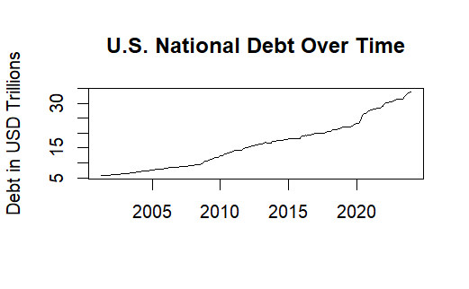

```r
plot(totaldebtdf$record_date, totaldebtdf$total_tril_amt,
     type='l',
     main="U.S. National Debt Over Time",
     xlab="",
     ylab="Debt in USD Trillions")
```

However, the `ggplot2` package provides lots of extra visualization functionality that can make the plotting process a bit smoother and more capable. Let’s replicate the above figure using `ggplot()` to see the differences.

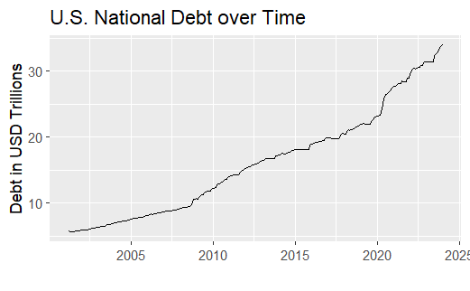

```r
ggplot(totaldebtdf,aes(x=record_date,y=total_tril_amt)) +
  geom_line() +
  ggtitle("U.S. National Debt over Time") +
  xlab("") +
  ylab("Debt in USD Trillions")
```

### Stacked Line Chart 1: Publicly Held Debt vs. Intragovernmental Holdings

A good way to visually dive deeper into the data is to decompose the debt into different categories based on the groupings provided. The first partition we can make is by debt holder. A portion of the national debt exists as a liability for one governmental agency and an asset for another agency (hence, intragovernmental holdings).

To compare across publicly held debt and intragovernmental holdings, we must first combine the two variables together using the `gather()` function (ggplot2 tends to prefer long panels, rather than wide panels of data), convert the values to trillions, and then plot the stacked area chart using `ggplot()` along with a few labeling options.

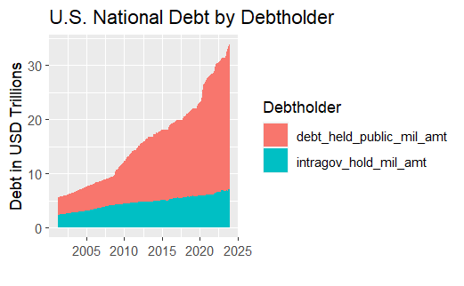

```r
# Extract relevant variables from totaldebtdf
helddf = totaldebtdf[,c("record_date","debt_held_public_mil_amt","intragov_hold_mil_amt")]
# Combine the two `mil_amt` variables into one and create a new variable `Holder` that indicates which observations belong to which category.
helddf = gather(helddf,"Holder","mil_amt",-record_date)
# Convert millions to trillions
helddf$tril_amt = helddf$mil_amt/1000000
# Plot stacked line chart
ggplot(helddf, aes(x=record_date, y=tril_amt, fill=Holder)) +
  geom_area(position='stack') +
  xlab("") +
  ylab("Debt in USD Trillions") +
  labs(title="U.S. National Debt by Debtholder",fill="Debtholder")
```

This shows that the intragovernmental holdings have tended to be more stable in their growth, whereas the publicly held debt has grown more rapidly over the past decade plus.

### Stacked Line Chart 2: Debt by Marketability

Another way to partition the data is by debt marketability, which is indicated by the `security_type_desc` variable in `debtdf`. This variable already is in a long panel format, so all we need to do is remove all the extra observations for the further subsets and aggregates. Practically, this is effectively the same partition as the previous debt holder split. So the main point for this is how one might plot such a stacked line chart when the group labels are in a single, categorical variable, rather than separate variables.

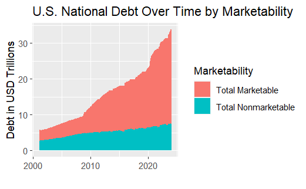

```r
# Extract relevant observations from debtdf (only need subtotals for marketable and nonmarketable debt)
stackdf = subset(debtdf,security_type_desc%in%c("Total Marketable","Total Nonmarketable"),)
# Plot stacked line chart (no extra steps since categories are already in correct vertical format)
ggplot(stackdf, aes(x=record_date, y=total_tril_amt, fill=security_type_desc)) +
  geom_area(position = 'stack') +
  xlab("") +
  ylab("Debt in USD Trillions") +
  labs(title="U.S. National Debt Over Time by Marketability",fill="Marketability")
```

### Stacked Line Chart 3: Debt by Security Class

Lastly, we can make use of all the smallest subsets to show a more detailed breakdown of the debt. However, due to the fairly large number of categories, the most optimal way to present this data likely would involve aggregating similar categories to maybe 4-5 groups.

[figure not shown]

```r
# Extract relevant observations (remove subtotals and totals; keep only the individual security classes)
secclassdf = subset(debtdf,security_class_desc!="_")
# Plot the stacked line chart
ggplot(secclassdf, aes(x=record_date, y=total_tril_amt, fill=security_class_desc)) +
  geom_area(position = 'stack') +
  xlab("") +
  ylab("Debt in USD Trillions") +
  labs(title="U.S. National Debt by Security Class",fill="Security Class")
```

### Histogram: Continuously Compounded Growth

As the final exercise in this demonstration, we will convert the monthly levels of the national debt into annualized growth measurements, which generally is the more appropriate format for analyzing financial data such as this. The rationale is a bit more statistically nuanced (see [Stationarity](https://www.r-econometrics.com/timeseries/stationarity/) and [Unit](https://medium.com/codex/unit-root-in-time-series-38d451d742ce) [Roots](https://www.mathworks.com/help/econ/unit-root-nonstationarity.html)), but the general idea is that these ‘log returns’ better approximated by the normal distribution than the ‘levels’ or ‘prices’ of financial variables. Thus, statistical inferences that rely on the assumption of normality are more appropriate when modelling stock returns, rather than stock prices.

The code chunk below combines a couple steps. The first thing to note is that when converting to rates of growth, we lose one observation of time. This is due to not having a previous (lag) value to compare the earliest observation to. Thus, we insert an `NA` to fill the lost observation with a missing value (the `c()` function combines two vectors into one). Then the differences in the natural logarithms of the national debt are taken, which effectively shifts units from levels to growth rates. Then lastly, we annualize the monthly growth rates by multiplying by 12, and convert to percentage units by multiplying by 100.

```r
totaldebtdf$annpct = c(-diff(log(totaldebtdf$total_tril_amt)),NA)*12*100
```

To visualize the historical growth rates, we plot each month’s annualized growth rate using bars `geom_col()`. This shows a fair amount of variation from month to month. To see a more informative trend over time, we also plot the rolling averages for windows of 12 months (red) and 60 months (blue). As can be seen in the figure, the larger the rolling window, the smoother the trend becomes.

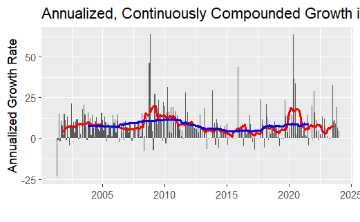

```r
ggplot(totaldebtdf,aes(x=record_date, y=annpct))+
  geom_col()+
  geom_line(aes(y=rollmean(annpct, 12, na.pad=TRUE)), colour="red", linewidth=1) +
  geom_line(aes(y=rollmean(annpct, 60, na.pad=TRUE)), colour="blue", linewidth=1) +
  ggtitle("Annualized, Continuously Compounded Growth in U.S. National Debt") +
  xlab("") +
  ylab("Annualized Growth Rate")
```

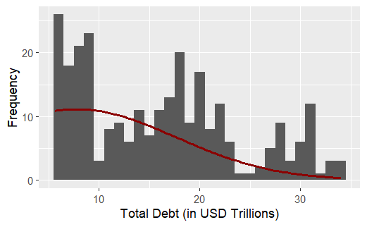

```r
# Set desired binwidth and number of non-missing obs
bw = 1
n_obs = sum(!is.na(totaldebtdf$annpct))

ggplot(totaldebtdf,aes(total_tril_amt)) +
  geom_histogram(binwidth=bw) +
  stat_function(fun=function(x) dnorm(x, mean=mean(totaldebtdf$annpct, na.rm=TRUE),   sd=sd(totaldebtdf$annpct, na.rm=TRUE)) * n_obs * bw, color = "darkred", linewidth = 1) +
  xlab("Total Debt (in USD Trillions)") +
  ylab("Frequency")
```

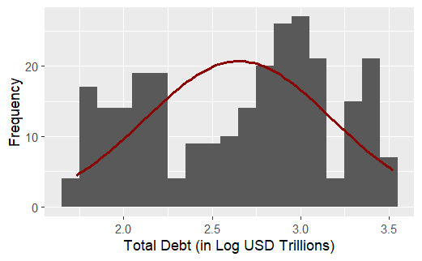

```r
ggplot(totaldebtdf,aes(log(total_tril_amt))) +
  geom_histogram(binwidth=0.1) +
  stat_function(fun=function(x) dnorm(x, mean=mean(log(totaldebtdf$total_tril_amt), na.rm=TRUE),   sd=sd(log(totaldebtdf$total_tril_amt), na.rm=TRUE)) * n_obs * 0.1, color = "darkred", linewidth = 1) +
  xlab("Total Debt (in Log USD Trillions)") +
  ylab("Frequency")
```

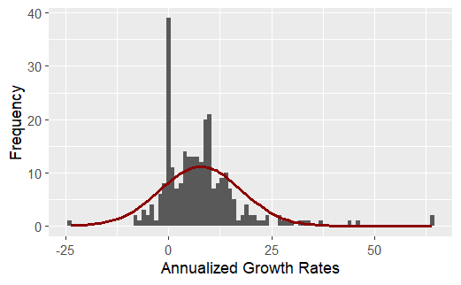

```r
ggplot(totaldebtdf,aes(annpct)) +
  geom_histogram(binwidth=bw) +
  stat_function(fun=function(x) dnorm(x, mean=mean(totaldebtdf$annpct, na.rm=TRUE),   sd=sd(totaldebtdf$annpct, na.rm=TRUE)) * n_obs * bw, color = "darkred", linewidth = 1) +
  xlab("Annualized Growth Rates") +
  ylab("Frequency")
```

## Summary Statistics

Lastly, let’s compute some summary statistics of the annualized growth rates to relate some numbers to the fitted bell curve above, which is defined by the mean and standard deviation. Additionally, the `summary()` function also provides the quartiles of the empirical distribution.

```r
mean(totaldebtdf$annpct, na.rm=TRUE) |> round(2)
```

```
[1] 7.79
```

```r
sd(totaldebtdf$annpct, na.rm=TRUE) |> round(2)
```

```
[1] 9.79
```

```r
summary(totaldebtdf$annpct) |> round(2)
```

```
   Min. 1st Qu.  Median    Mean 3rd Qu.    Max.    NA's
 -23.59    0.58    6.70    7.79   11.19   64.02       1
```